# Scenario: Boat Harvest Implementation @ Nisqually

Describing the model run when boat-based harvest is amplified above incidental levels at Nisqually

October 22, 2024

### The Narrative

This Model Run is for a scenario where managers open harvest of seals in the gauntlet by fishing vessels during the Chinook, Coho, and Chum fisheries. This is modeled similarly to incidental fishery take but at a higher exploitation rate.

### Run the Model

Parameters listed below are altered from the base run parameterization to simulate the management scenario. For this scenario we’re altering the shape of the relationship between the number of fishers in the system and the magnitude of harvest that occurs.

```r
# adjust parameters for management scenario
steepness_H <- 5 # how quick does it saturate (higher = slower)
efficiency <- 0.25 # what prop of seals are they capable of taking
```

### Description of Parameterization

This scenario is focused on the effects of a management strategy that changes the quantity of seal harvest. Removals occur on days when fishers are active in the gauntlet. The harvest strategy is still boat-based like incidental harvest but it is more aggressive as it is focused on seal removal directly not incidentally as in the base run.

When there are 150 harbor seals, 80 California sea lions, and 10 Steller sea lions in the source pool, daily pinniped presence at the Gauntlet is as follows:

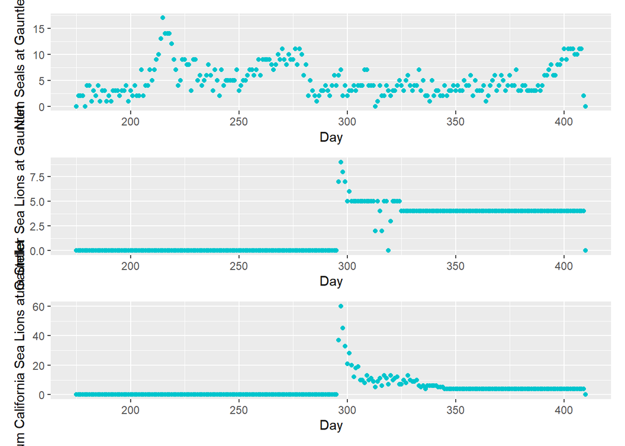

…and when there are 30 individual pinnipeds at the Gauntlet, removals are a type 2 function as follows:

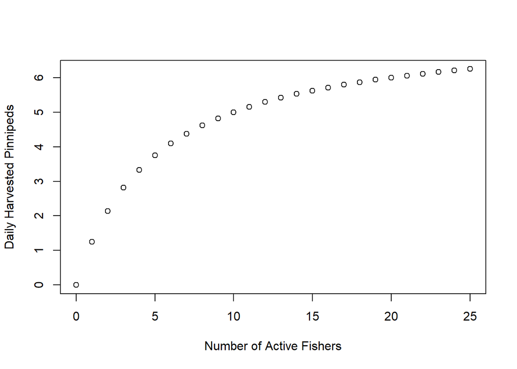

The harvest efficiency is set at 0.25, which represents both the proportion of pinnipeds in the gauntlet that are available to harvesters multiplied by the proportion of pinnipeds that harvesters are able to kill of the ones they attempt. In the Nisqually, I assume that fishers encounter 50% of seals while fishing in the main channel. I then assume that fishers kill 50% of the pinnipeds they encounter. This results in a 0.25 harvest efficiency for boat-based effort by Nisqually fishers.

I also increase the proportion of fishers who are engaging in harvest activity by increasing the rate at which the type II functional response that defines harvest per fisher reaches saturation. So in practice it takes fewer fishers on the water in a given day for the max seals to be harvested.

The number of boats participating in harvest is an average for the Chinook and Coho fisheries from 2017-2023 which comes out to 14 boats per day. For Chum, I have catch data from Craig Smith and the number of boats per day from 2014-2019 ranges from 1-25, so each day of the Chum fishery it does a random sample of 1:25 to determine the number of harvesters active that day.

The total harvested pinnipeds are as follows under this parameterization:

Harvested Pinnipeds

| Pv | Ej | Zc |
| --- | --- | --- |
| 36 | 6 | 76 |

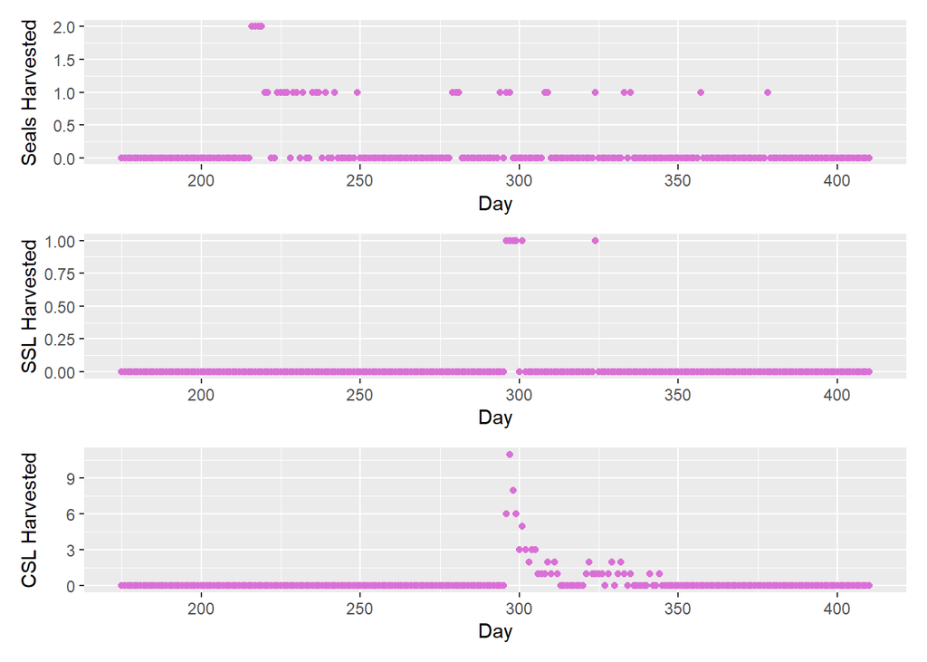

This level of harvest impacts the fear response of the pinnipeds that are exposed to harvest and causes fewer of them to go to the Gauntlet than in the base run. The below plots show the impact of harvest on fear conditioning of California sea lions as an example.

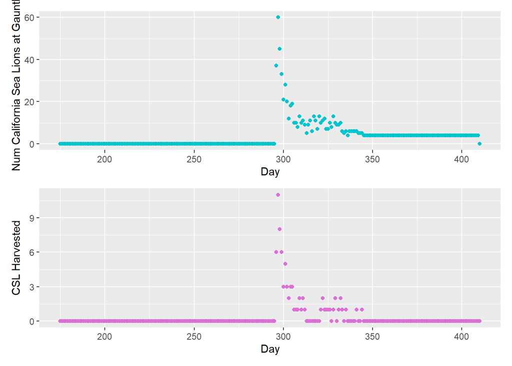

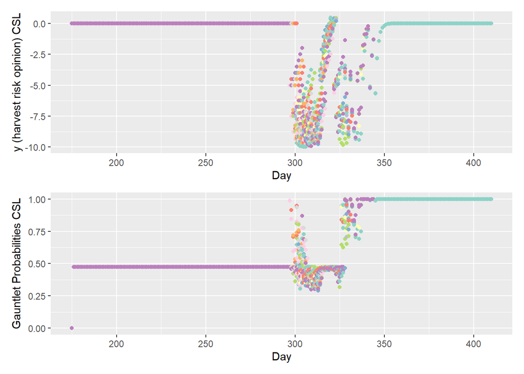

California Sea Lions arrive at the Gauntlet only for the Chum run, and so are mostly exposed to harvest during the Chum fishery. Harbor seals, in contrast, are exposed to harvest during all Nisqually Tribal fisheries (Chinook, Coho, and Chum) and their behavior is impacted accordingly as seen below.

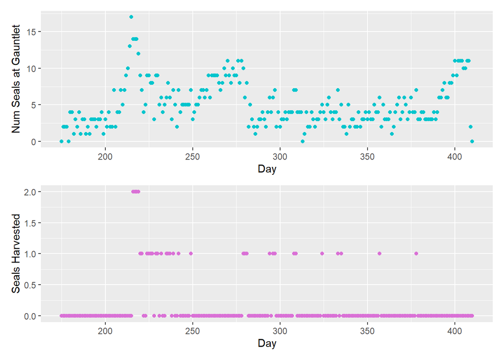

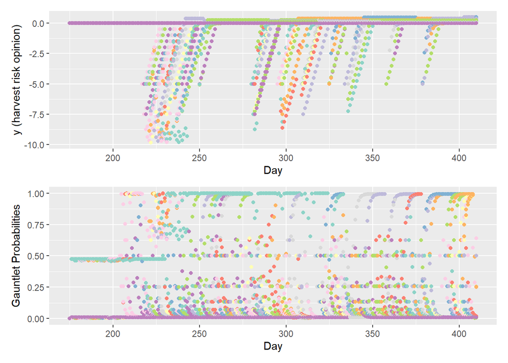

### Salmon Response

|  | Chum | Chinook_GR | Chinook_LN |
| --- | --- | --- | --- |
| Escape | 11033 | 12619 | 499 |
| Catch | 6303 | 4971 | 83 |
| Predated | 8272 | 2218 | 218 |

### Parameter Table

Here’s a parameter list:

|  | Value |
| --- | --- |
| days | 236.00 |
| num_seals | 150.00 |
| num_zc | 80.00 |
| num_ej | 10.00 |
| chum_residence | 21.00 |
| gr_residence | 14.00 |
| locnis_residence | 7.00 |
| chin_boats | 14.00 |
| min_chum_boats | 1.00 |
| max_chum_boats | 25.00 |
| steepness_H | 5.00 |
| efficiency | 0.25 |